# Mid-semester review and prep for final project

## Outline for today’s class

- Evals (short discussion)
- What is advanced data analysis?
- Overview of key points from each class, model characteristics, R output, diagnostics interpretations
- Final project overview, discussion of datasets

## Evals

- Thank you for the input!
- More cowbell (analysis) please!
- More experience with Github
- What is advanced data analysis?

[figure not shown]

## What is advanced data analysis?

- Envisioned in part as teaching students how NOT TO DO crappy science (or how TO DO good science)

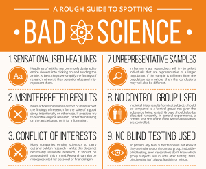

- In our program, first year classes (biostats, epi methods, ALM) provide an introduction to different models used in statistical analysis without getting much into all the different components that go into producing a solid statistical evaluation of a public health problem.
- **AND** of course all along the way much experience is obtained with statisitcal software (R in this case) and data management

## What consitutes good science? (My top 5)

1. A reproducible work flow so that 10 years from now or even just 6 months from now you or someone else can reproduce the results from a publication or report, **exactly**. What information do you need to provide to help ensure reproducibility?
2. Knowledge of the main statistical models used to analyze public health problems, when they are appropriate, when they are not appropriate, what you should do to assess model fit/diagnostics.
3. Adjusting for covariates using DAGs. We SHOULD NOT throw the kitchen sink in the model. This is a tricky business and we need to use a systematic way of covariate selection based on logic and practical issues.
4. Robustness checks–when uncertain of what the best model is, do it multiple ways, also do sensitivity analyses to see if conclusions change based on your CHOICE of how to model the data.
5. *Accurate* communication of findings

## CLASS ONE

- We will come back to this and look at the survey data for common interests that may help us with ideas for final projects!

## CLASS TWO-Reproducible Research

- What are the main components?
  - Publication + Linked and executable code and data (Peng!!)
- Literate programming with RMD
- Introduce and explain code (prolog and annotation)
- Choose meaningful names with consistent formatting for datasets, variables, etc.
- Using space wisely

## CLASS THREE-Git and Github for version control

- MORE PRACTICE PLEASE!!
- I suggest that you use it with your group or with yourself for the final project! This will help you learn it *well* while putting the time to good use!! USE IT OR LOSE IT…
- Key basic commands for working with Git
  - `$ Git init`
  - `$ Git add`
  - `$ Git commit`
  - `$ Git push`
  - `$ Git pull`

## CLASS FOUR: Data visualization

- Visual display is a critical component to understanding the data and modeling it AND great visual display is important for communication of scientific findings

## CLASS FIVE: Logistic regression

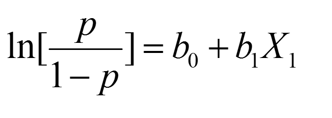

- **Dependent variable:** Binary variable
- **Independent variable:** Categorical and continuous
- **Measure of Association:** Odds ratio (OR) (exp of B from the model)
- **Model assumptions:** Several
- **What does the model predict?**
  - The probability that an observation falls into one category given the independent variables
  - The log odds that an observation falls into one category given independent variables
- **Model things to check:**
  - liklihood ratio test
    - deviance = -2 X log-likelihood
    - null deviance = model without any predictors
    - residual deviance=model with predictors
    - liklihood ratio test = null deviance - residual deviance = chi-square with df from base model - df from full model (i.e. with additional predictor(s))

*Note to compare models you need to make sure they include the same number of observations (nested models)

- **Sensitivity and specificity of the model (model fit–how well does the model do at classifying people correctly)**
- **How do we interpret the results?** Go to class 5 demo

## CLASS SIX: Multinomial logistic regression

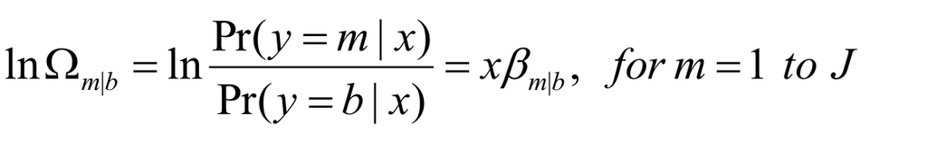

- **Dependent variable:** Categorical variable with J levels
- **Independent variable:** Continuous or categorical
- **Measure of Association:** Odds ratio (OR) (exp of B from the model)
- **Model assumptions:** several
- **What does the model predict?**
  - The probability that an observation falls into category J given independent variables
  - The log odds of that an observation falls into category J given independent variables
- **Model fit**-Can compare two models using the Liklihood ratio test
- **How do we interpret the results?**
  - The effect of independent variables on the probability of category J, in comparison to the reference category.

## CLASS SIX: Ordinal logistic regression

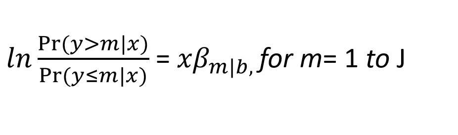

- **Dependent variable:** ordered categorical variable with J levels
- **Independent variable:** Continuous or categorical
- **Measure of Assocation:** Odds Ratio (exp of B from the model)
- **Model assumptions:** proportional odds assumption (can be tested by comparing deviances between multinomial and ordinal model, from pg. 272 Fox and Weisberg “An R companion to Applied Regression 2nd edition”)

```r
#made up example--the df is the difference between the two model dfs
pchisq(deviance(mod.polr) - deviance(mod.multinom), df= 6-4, lower.tail=FALSE)
library(readr) #for read txt file
library(knitr) #for creating nicer tables
library(tidyverse) # for various packages
Breast_SEER_Class6 <- read_delim("/Users/candice_wang/Box Sync/2018 Spring/TA/Class 6_my/Final/Breast_SEER_Class6.txt", "\t", escape_double = FALSE, trim_ws = TRUE)
names(Breast_SEER_Class6)<-c("Age", "Race", "Sex", "Diagnosis_year", "Stage", "First", "PatientID", "Insur", "Marital", "Poverty")
Data <- Breast_SEER_Class6 %>%
   mutate(Male_cat=factor(Sex),
         First_cat=factor(First),
         Age_num=as.numeric(gsub("([0-9]+).*$", "\\1",Age)),
         #Non-Black as reference
         Black_cat=ifelse(Race=="White"
                         |Race=="Other (American Indian/AK Native, Asian/Pacific Islander)", 0,
                            ifelse(Race=="Black", 1, NA)),
         Black_cat=factor(Black_cat, levels=0:1, labels = c("Non-Black", "Black")),
         #Stage I as reference
         Stage_cat=ifelse(Stage == "IA" | Stage == "IB", 0,
                         ifelse(Stage == "IIA" | Stage == "IIB",1,
                                ifelse(Stage == "IIIA" |Stage == "IIIA"
                                       |Stage == "IIIC" |Stage =="IIINOS",2,
                                       ifelse(Stage =="IV", 3, NA)))),
         Stage_cat=factor(Stage_cat, levels=0:3, labels=c ("StageI", "StageII", "StageIII", "StageIV")),
         #Uninsured as reference
         Insur_cat = ifelse(Insur == "Uninsured",0,
                            ifelse(Insur == "Any Medicaid" ,1,
                                   ifelse(Insur == "Insured"
                                          |Insur == "Insured/No specifics", 2, NA))),
         Insur_cat=factor(Insur_cat, levels=0:2, labels=c ("Uninsured", "Medicaid", "Insured"))
           )
Data1 <- Data %>%
  filter(First_cat!="No"&!is.na(Stage_cat)&!is.na(Insur_cat)&!is.na(Black_cat)&!is.na(Age_num)&!is.na(Male_cat))
attach(Data1)
Stage_cat_re <- relevel(Stage_cat, ref = "StageIV")
##Execute a mutilnomial regression with insurance as independent variable and demographics as covariates
mod <- multinom(Stage_cat_re ~ Insur_cat + Age_num + Male_cat + Black_cat)
summary(mod)
mod1 <- polr(Stage_cat ~ Insur_cat + Age_num + Male_cat + Black_cat, Hess=TRUE)
summary(mod1)
lrtest(mod, mod1)
#by hand
dif<-abs(mod$deviance-mod1$deviance)
dif
pchisq(dif,df=18-8,lower.tail=FALSE)
```

- **What does the model predict?**
  - The probability that an observation falls into category J or higher given independent variables
  - The log odds of being in a category higher than J relative to category J or lower given independent variables
- **How do we interpret the results?**
  - The effect of independent variables on the probability of category J or Js, in comparison to the higher categories.

## CLASS SEVEN: Poisson regression

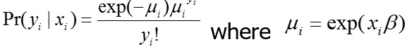

- u is known as the rate and is the expected number of times that an event has occurred per unit of time.
- **Model assumptions:**
  - Conditional variance equals the conditional mean
- **Dependent variable:** Count
- **Independent variables:** Continuous or categorical
- **Measure of association:** Incidence rate ratio (IRR) (exp of B from the model)
- **How do we interpret the results?**
  - For a unit change in x<sub>k</sub>, the expected count changes by a factor of expB<sub>k</sub>, other things being equal
- **What to watch out for:** Overdispersion, lots of 0’s (zero inflated), no 0’s (zero truncated)

## CLASS SEVEN: Negative Binomial regression

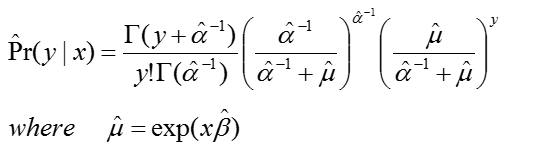

- Use when there is overdispersion
- **Model assumptions:**
  - Conditional variance equals the conditional mean *plus* an overdispersion parameter (alpha) multiplied by a quadratic term of the mean
- **Dependent variable:** Count
- **Independent variables:** Continuous or categorical
- **Measure of association:** Incidence rate ratio (IRR) (exp of B from the model)
- **How do we interpret the results?** Same as Poisson
- **What to watch out for:** lots of 0’s (zero inflated), no 0’s (zero truncated)

## Marginal effects (all models)

- See https://cran.r-project.org/web/packages/margins/vignettes/TechnicalDetails.pdf for more reading
- **Marginal effects at representative values (MERs):** Fitted values at representative values of X
- **Marginal effects at the mean of X (MEMs):** not particularly useful
- **Average marginal effects (AMEs):** calculates a fitted value y-hat for every observed value of X and then averages them

## Final project

- Concept proposal
- How you might you approach this
- **Potential datasets**
  - NHANES
  - SEER
  - BRFSS
  - HINTS
  - https://www.healthdata.gov/ to search potential datasets